# Project Python Foundations: FoodHub Data Analysis

### Context

The number of restaurants in New York is increasing day by day. Lots of students and busy professionals rely on those restaurants due to their hectic lifestyles. Online food delivery service is a great option for them. It provides them with good food from their favorite restaurants. A food aggregator company FoodHub offers access to multiple restaurants through a single smartphone app.

The app allows the restaurants to receive a direct online order from a customer. The app assigns a delivery person from the company to pick up the order after it is confirmed by the restaurant. The delivery person then uses the map to reach the restaurant and waits for the food package. Once the food package is handed over to the delivery person, he/she confirms the pick-up in the app and travels to the customer's location to deliver the food. The delivery person confirms the drop-off in the app after delivering the food package to the customer. The customer can rate the order in the app. The food aggregator earns money by collecting a fixed margin of the delivery order from the restaurants.

### Objective

The food aggregator company has stored the data of the different orders made by the registered customers in their online portal. They want to analyze the data to get a fair idea about the demand of different restaurants which will help them in enhancing their customer experience. Suppose you are hired as a Data Scientist in this company and the Data Science team has shared some of the key questions that need to be answered. Perform the data analysis to find answers to these questions that will help the company to improve the business.

### Data Description

The data contains the different data related to a food order. The detailed data dictionary is given below.

### Data Dictionary

- order_id: Unique ID of the order
- customer_id: ID of the customer who ordered the food
- restaurant_name: Name of the restaurant
- cuisine_type: Cuisine ordered by the customer
- cost_of_the_order: Cost of the order
- day_of_the_week: Indicates whether the order is placed on a weekday or weekend (The weekday is from Monday to Friday and the weekend is Saturday and Sunday)
- rating: Rating given by the customer out of 5
- food_preparation_time: Time (in minutes) taken by the restaurant to prepare the food. This is calculated by taking the difference between the timestamps of the restaurant's order confirmation and the delivery person's pick-up confirmation.
- delivery_time: Time (in minutes) taken by the delivery person to deliver the food package. This is calculated by taking the difference between the timestamps of the delivery person's pick-up confirmation and drop-off information

### Import the required libraries

```python
# import libraries for data manipulation
import numpy as np
import pandas as pd

# import libraries for data visualization
import matplotlib.pyplot as plt
import seaborn as sns
```

### Understanding the structure of the data

```python
# Mount Google Drive
from google.colab import drive
drive.mount('/content/drive')
```

```python
# Read dataset from Google Drive
df = pd.read_csv('/content/drive/MyDrive/Colab Notebooks/foodhub_order.csv')
```

```python
# View the first 5 rows
df.head()
```

|  | order_id | customer_id | restaurant_name | cuisine_type | cost_of_the_order | day_of_the_week | rating | food_preparation_time | delivery_time |
| --- | --- | --- | --- | --- | --- | --- | --- | --- | --- |
| 0 | 1477147 | 337525 | Hangawi | Korean | 30.75 | Weekend | Not given | 25 | 20 |
| 1 | 1477685 | 358141 | Blue Ribbon Sushi Izakaya | Japanese | 12.08 | Weekend | Not given | 25 | 23 |
| 2 | 1477070 | 66393 | Cafe Habana | Mexican | 12.23 | Weekday | 5 | 23 | 28 |
| 3 | 1477334 | 106968 | Blue Ribbon Fried Chicken | American | 29.20 | Weekend | 3 | 25 | 15 |
| 4 | 1478249 | 76942 | Dirty Bird to Go | American | 11.59 | Weekday | 4 | 25 | 24 |

### **Question 1:** How many rows and columns are present in the data? [0.5 mark]

```python
# Check shape of the data
print('Number of rows: ', df.shape[0])
print('Number of columns: ', df.shape[1])
```

```
Number of rows:  1898
Number of columns:  9
```

#### Observations:

The dataset contain 1898 rows and 9 columns

### **Question 2:** What are the datatypes of the different columns in the dataset? (The info() function can be used) [0.5 mark]

```python
# Check datatype of each column
df.info()
```

```
<class 'pandas.core.frame.DataFrame'>
RangeIndex: 1898 entries, 0 to 1897
Data columns (total 9 columns):
 #   Column                 Non-Null Count  Dtype
---  ------                 --------------  -----
 0   order_id               1898 non-null   int64
 1   customer_id            1898 non-null   int64
 2   restaurant_name        1898 non-null   object
 3   cuisine_type           1898 non-null   object
 4   cost_of_the_order      1898 non-null   float64
 5   day_of_the_week        1898 non-null   object
 6   rating                 1898 non-null   object
 7   food_preparation_time  1898 non-null   int64
 8   delivery_time          1898 non-null   int64
dtypes: float64(1), int64(4), object(4)
memory usage: 133.6+ KB
```

#### Observations:

The dataset contains columns with integer, float and object (string) datatypes.

order_id, customer_id, food_preparation_time and delivery_time are integers.

cost_of_the_order is float

restaurant_name, cuisine_type, day_of_the_week and rating are objects.

The data type of rating column is object, it's due to the records stored as 'Not given'

### **Question 3:** Are there any missing values in the data? If yes, treat them using an appropriate method. [1 mark]

```python
# Check missing values
df.isnull().sum()
```

|  | 0 |
| --- | --- |
| order_id | 0 |
| customer_id | 0 |
| restaurant_name | 0 |
| cuisine_type | 0 |
| cost_of_the_order | 0 |
| day_of_the_week | 0 |
| rating | 0 |
| food_preparation_time | 0 |
| delivery_time | 0 |

**dtype:** int64

#### Observations:

There are no missing values in the data

Data in rating column is stored as object, entries like 'Not given' are missing values

```python
df['rating'].unique()
```

```
array(['Not given', '5', '3', '4'], dtype=object)
```

Changing data type of rating column to numeric

```python
df['rating'] = pd.to_numeric(df['rating'], errors='coerce')
```

```python
# checking the count of different data types in rating column
df['rating'].apply(type).value_counts()
```

| rating | count |
| --- | --- |
| <class 'float'> | 1898 |

**dtype:** int64

```python
# Checking unique values for rating column
df['rating'].unique()
```

```
array([nan,  5.,  3.,  4.])
```

### **Question 4:** Check the statistical summary of the data. What is the minimum, average, and maximum time it takes for food to be prepared once an order is placed? [2 marks]

```python
# Statistical summary of the data
df.describe().T
```

|  | count | mean | std | min | 25% | 50% | 75% | max |
| --- | --- | --- | --- | --- | --- | --- | --- | --- |
| order_id | 1898.0 | 1.477496e+06 | 548.049724 | 1476547.00 | 1477021.25 | 1477495.50 | 1.477970e+06 | 1478444.00 |
| customer_id | 1898.0 | 1.711685e+05 | 113698.139743 | 1311.00 | 77787.75 | 128600.00 | 2.705250e+05 | 405334.00 |
| cost_of_the_order | 1898.0 | 1.649885e+01 | 7.483812 | 4.47 | 12.08 | 14.14 | 2.229750e+01 | 35.41 |
| rating | 1162.0 | 4.344234e+00 | 0.741478 | 3.00 | 4.00 | 5.00 | 5.000000e+00 | 5.00 |
| food_preparation_time | 1898.0 | 2.737197e+01 | 4.632481 | 20.00 | 23.00 | 27.00 | 3.100000e+01 | 35.00 |
| delivery_time | 1898.0 | 2.416175e+01 | 4.972637 | 15.00 | 20.00 | 25.00 | 2.800000e+01 | 33.00 |

#### Observations:

The average food preparation time is around 27.37

Food preparation time ranges from 20-35 minutes

Minimum time to prepare food is 20 minutes

Maximum time to prepare food is 35 minutes

### **Question 5:** How many orders are not rated? [1 mark]

```python
# Orders with no ratings
df['rating'].isnull().sum()
```

```
np.int64(736)
```

#### Observations:

There are 736 orders not rated by the customers

Since the rating column is customer feedback, replacing nan values with mean or mod might skew the perception of customer satisfaction. It's more appropriate to replace these rating with '0' or acknowledge these as not rated by the customers if these don't impact the analysis.

### Exploratory Data Analysis (EDA)

### **Question 6:** Explore all the variables and provide observations on their distributions. (Generally, histograms, boxplots, countplots, etc. are used for univariate exploration.) [9 marks]

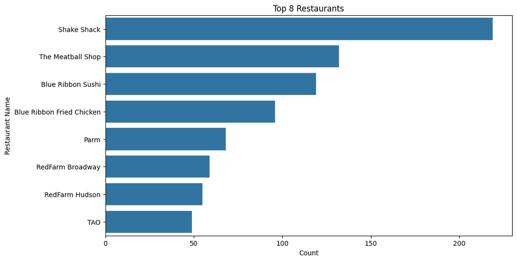

```python
# Resturanct_name
plt.figure(figsize=(11,6))
sns.countplot(data=df, y='restaurant_name', order=df['restaurant_name'].value_counts().index[:8])
plt.title('Top 8 Restaurants')
plt.xlabel('Count')
plt.ylabel('Restaurant Name')
plt.show()
```

### Observation

Shake Shake is a popular choice among customer

Some resturants receive significantly more orders than others

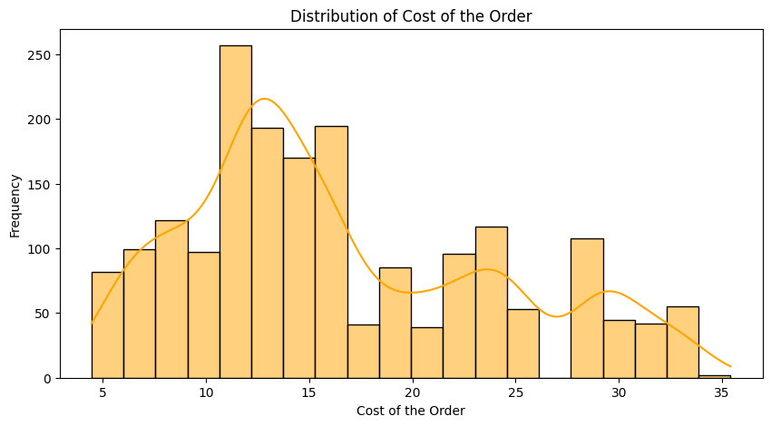

```python
# cost_of_the_order
plt.figure(figsize=(10,5))
sns.histplot(data=df, x='cost_of_the_order', bins=20, kde=True, color='orange')
plt.title('Distribution of Cost of the Order')
plt.xlabel('Cost of the Order')
plt.ylabel('Frequency')
plt.show()
```

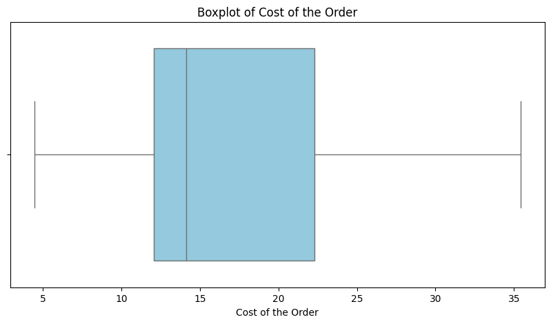

```python
plt.figure(figsize=(10,5))
sns.boxplot(data=df, x='cost_of_the_order', color='skyblue')
plt.title('Boxplot of Cost of the Order')
plt.xlabel('Cost of the Order')
plt.show()
```

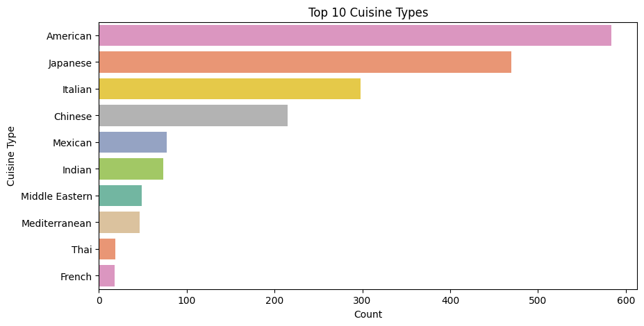

```python
# cuisine_type
plt.figure(figsize=(10,5))
sns.countplot(data=df, y='cuisine_type', order=df['cuisine_type'].value_counts().index[:10], hue='cuisine_type', palette='Set2', legend=False)
plt.title('Top 10 Cuisine Types')
plt.xlabel('Count')
plt.ylabel('Cuisine Type')
plt.show()
```

### Observation

American and Japenese cusines are most frequently ordered. French and Thai are less common.

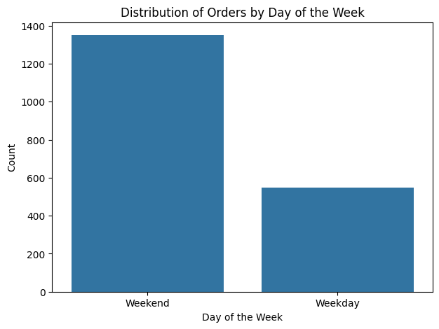

```python
# day_of_the_week
plt.figure(figsize=(7,5))
sns.countplot(data=df, x='day_of_the_week')
plt.title('Distribution of Orders by Day of the Week')
plt.xlabel('Day of the Week')
plt.ylabel('Count')
plt.show()
```

### Observation

A significantly higher number of orders are placed during the weekend, compared to weekdays.

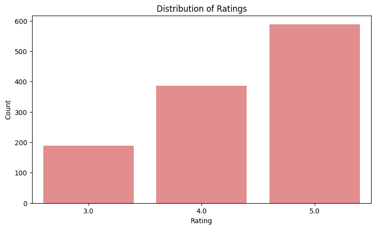

```python
# rating
plt.figure(figsize=(9,5))
sns.countplot(data=df, x='rating', color='lightcoral')
plt.title('Distribution of Ratings')
plt.xlabel('Rating')
plt.ylabel('Count')
plt.show()
```

### Observation

Rating of 4 and 5 are common, indicating high customer satisfaction

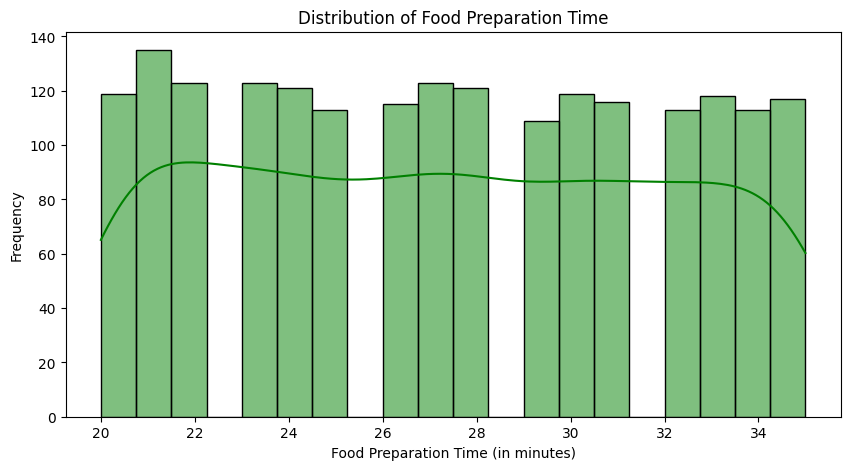

```python
# food_preparation_time
plt.figure(figsize=(10,5))
sns.histplot(data=df, x='food_preparation_time', bins=20, kde=True, color='green')
plt.title('Distribution of Food Preparation Time')
plt.xlabel('Food Preparation Time (in minutes)')
plt.ylabel('Frequency')
plt.show()
```

### Observation

The food Preparation time is fairly uniform, ranging between 20-35 minutes. No significant outliers.

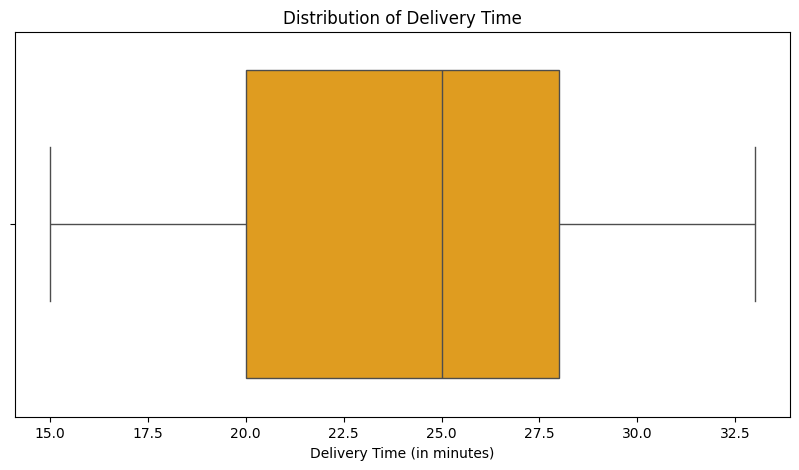

```python
# delivery_time
plt.figure(figsize=(10,5))
sns.boxplot(data=df, x='delivery_time', color='orange')
plt.title('Distribution of Delivery Time')
plt.xlabel('Delivery Time (in minutes)')
plt.show()
```

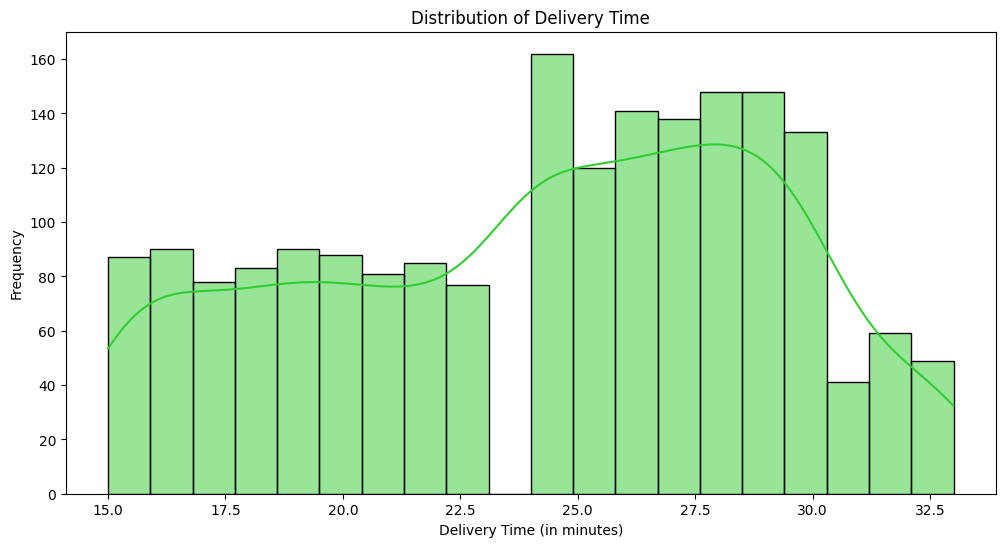

```python
plt.figure(figsize=(12,6))
sns.histplot(data=df, x='delivery_time', bins=20, kde=True, color='limegreen')
plt.title('Distribution of Delivery Time')
plt.xlabel('Delivery Time (in minutes)')
plt.ylabel('Frequency')
plt.show()
```

### **Question 7**: Which are the top 5 restaurants in terms of the number of orders received? [1 mark]

```python
# top five resturants based on number of orders
df['restaurant_name'].value_counts()[:5]
```

| restaurant_name | count |
| --- | --- |
| Shake Shack | 219 |
| The Meatball Shop | 132 |
| Blue Ribbon Sushi | 119 |
| Blue Ribbon Fried Chicken | 96 |
| Parm | 68 |

**dtype:** int64

#### Observations:

Shake Shack is significantly ahead of others, followed by the Meatball Shop and Ribbon Sushi.

### **Question 8**: Which is the most popular cuisine on weekends? [1 mark]

```python
# Most popular cuisine on weekends
most_popular_weekend_cuisine = df[df['day_of_the_week'] == 'Weekend']['cuisine_type'].value_counts().idxmax()
most_popular_weekend_cuisine
```

```
'American'
```

#### Observations:

American cuisine is the most popular on weekends.

### **Question 9**: What percentage of the orders cost more than 20 dollars? [2 marks]

```python
# Orders with cost more than 20 dollars
high_cost_orders = df[df['cost_of_the_order'] >20]
percentage_high_cost_orders = (len(high_cost_orders) / len(df)) * 100
percentage_high_cost_orders
```

```
29.24130663856691
```

#### Observations:

29.24% of the orders cost more than 20 dollars.

### **Question 10**: What is the mean order delivery time? [1 mark]

```python
# Mean delivery time
mean_delivery_time = df['delivery_time'].mean()
print('Mean delivery time: ', mean_delivery_time)
```

```
Mean delivery time:  24.161749209694417
```

#### Observations:

The mean of delivery time for all orders is 24.16 minutes

### **Question 11:** The company has decided to give 20% discount vouchers to the top 3 most frequent customers. Find the IDs of these customers and the number of orders they placed. [1 mark]

```python
# Top 3 customers
top_3_customer = df['customer_id'].value_counts()[:3]
top_3_customer
```

| customer_id | count |
| --- | --- |
| 52832 | 13 |
| 47440 | 10 |
| 83287 | 9 |

**dtype:** int64

#### Observations:

The top three most frequent customer id's who will receive 20% discount are:

52832 with 13 orders, 47440 with 10 orders, 83287 with 9 orders.

### **Question 12**: Perform a multivariate analysis to explore relationships between the important variables in the dataset. (It is a good idea to explore relations between numerical variables as well as relations between numerical and categorical variables) [10 marks]

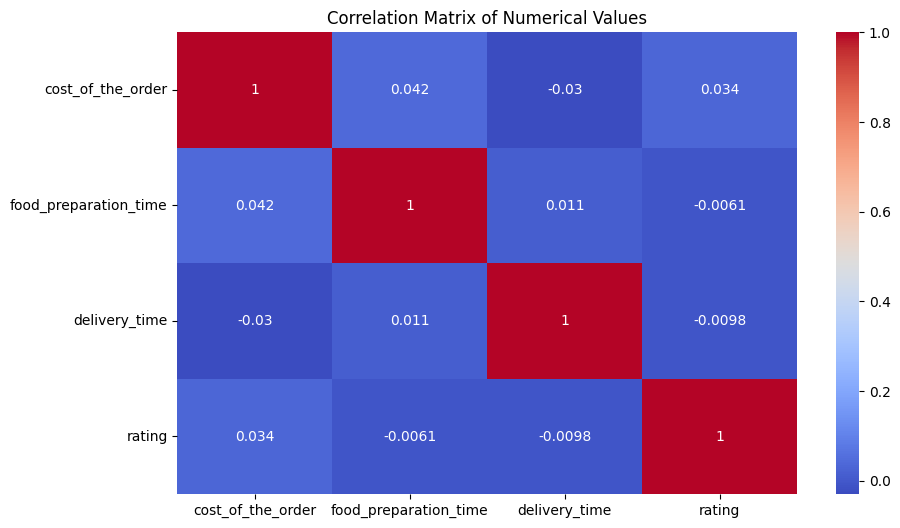

```python
# correlation matrix and heat: numerical values
plt.figure(figsize=(10,6))
sns.heatmap(df[['cost_of_the_order', 'food_preparation_time', 'delivery_time', 'rating']].corr(), annot=True, cmap='coolwarm')
plt.title('Correlation Matrix of Numerical Values')
plt.show()
```

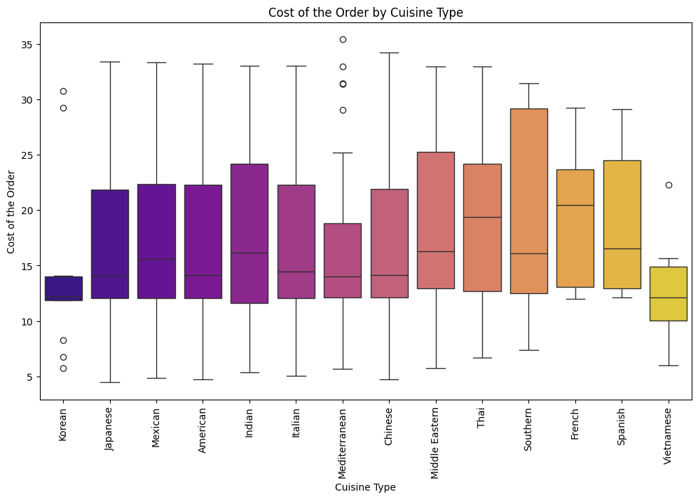

```python
# categorical vs numerical variables
plt.figure(figsize=(12,7))
sns.boxplot(data=df, x='cuisine_type', y='cost_of_the_order', palette='plasma', hue='cuisine_type', legend=False)
plt.title('Cost of the Order by Cuisine Type')
plt.xticks(rotation=90)
plt.xlabel('Cuisine Type')
plt.ylabel('Cost of the Order')
plt.show()
```

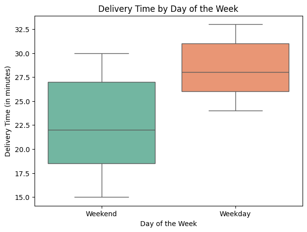

```python
# Day of the week and delivery time
plt.figure(figsize=(7,5))
sns.boxplot(data=df, x='day_of_the_week', y='delivery_time', palette='Set2', hue='day_of_the_week', legend=False)
plt.title('Delivery Time by Day of the Week')
plt.xlabel('Day of the Week')
plt.ylabel('Delivery Time (in minutes)')
plt.show()
```

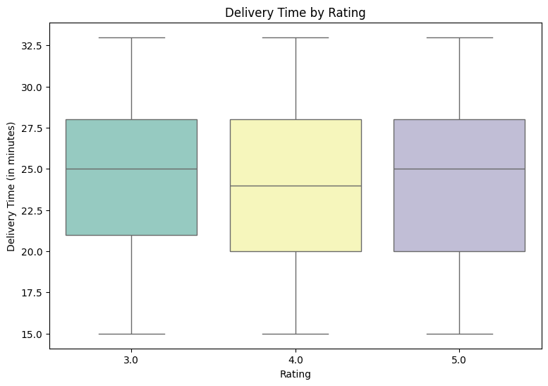

```python
# Rating and Delivery time
plt.figure(figsize=(9,6))
sns.boxplot(data=df, x='rating', y='delivery_time', palette='Set3', hue='rating', legend=False)
plt.title('Delivery Time by Rating')
plt.xlabel('Rating')
plt.ylabel('Delivery Time (in minutes)')
plt.show()
```

### Observation

Delivery time does not impact rating negatively or positively

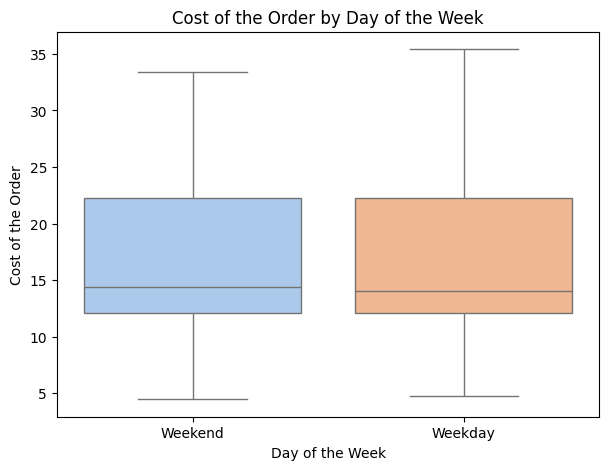

```python
# Day of the week vs Cost of the order
plt.figure(figsize=(7,5))
sns.boxplot(data=df, x='day_of_the_week', y='cost_of_the_order', palette='pastel', hue='day_of_the_week', legend=False)
plt.title('Cost of the Order by Day of the Week')
plt.xlabel('Day of the Week')
plt.ylabel('Cost of the Order')
plt.show()
```

### Observation

Higher volume of orders on the weekends, median cost of orders is higher on weekends compared to weekdays

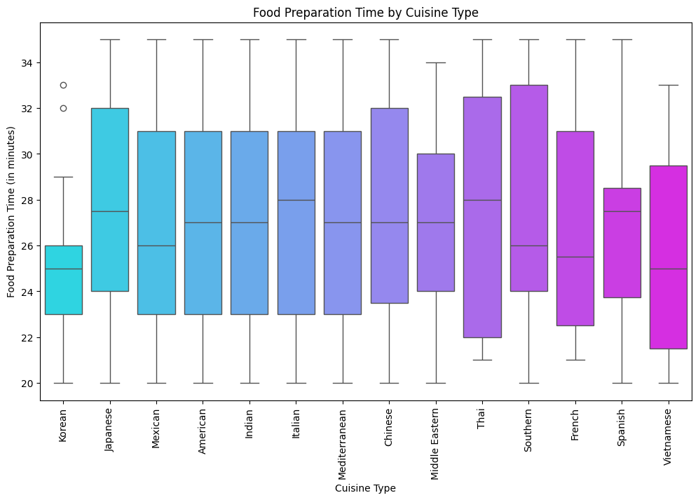

```python
# Cuisine type and Food preparation time
plt.figure(figsize=(12,7))
sns.boxplot(data=df, x='cuisine_type', y='food_preparation_time', palette='cool', hue='cuisine_type', legend=False)
plt.title('Food Preparation Time by Cuisine Type')
plt.xticks(rotation=90)
plt.xlabel('Cuisine Type')
plt.ylabel('Food Preparation Time (in minutes)')
plt.show()
```

### Observation

Preparation times are similar across most cuisine types

### **Question 13:** The company wants to provide a promotional offer in the advertisement of the restaurants. The condition to get the offer is that the restaurants must have a rating count of more than 50 and the average rating should be greater than 4. Find the restaurants fulfilling the criteria to get the promotional offer. [3 marks]

```python
# Resturants that meet the promotion criteria
df_rated = df[df['rating'].notnull()]
rating_counts = df_rated.groupby('restaurant_name')['rating'].count()
avg_ratings = df_rated.groupby('restaurant_name')['rating'].mean()
resturant_rating_summary = pd.DataFrame({'rating_count': rating_counts, 'avg_rating': avg_ratings})
eligible_resturants = resturant_rating_summary[(resturant_rating_summary['rating_count'] > 50) & (resturant_rating_summary['avg_rating'] > 4)]
eligible_resturants
```

| restaurant_name | rating_count | avg_rating |
| --- | --- | --- |
| Blue Ribbon Fried Chicken | 64 | 4.328125 |
| Blue Ribbon Sushi | 73 | 4.219178 |
| Shake Shack | 133 | 4.278195 |
| The Meatball Shop | 84 | 4.511905 |

#### Observations:

Based on the criteria provided, the following four resturants qualify for the promo

### **Question 14:** The company charges the restaurant 25% on the orders having cost greater than 20 dollars and 15% on the orders having cost greater than 5 dollars. Find the net revenue generated by the company across all orders. [3 marks]

```python
# Revenue for all orders
df_revenue = 0

# Calculating revenue for each order
for index, row in df.iterrows():
    order_cost = row['cost_of_the_order']
    if order_cost > 20:
        df_revenue += order_cost * 0.25
    elif order_cost > 5:
        df_revenue += order_cost * 0.15

print('Net revenue generated by the company across all orders: ', df_revenue)
```

```
Net revenue generated by the company across all orders:  6166.302999999994
```

#### Observations:

Given the commission structure, total revenue generated by the company is 6166.30

### **Question 15:** The company wants to analyze the total time required to deliver the food. What percentage of orders take more than 60 minutes to get delivered from the time the order is placed? (The food has to be prepared and then delivered.) [2 marks]

```python
# Total delivery time
df_total_time = df['food_preparation_time'] + df['delivery_time']
percentage_above_60 = (len(df_total_time[df_total_time > 60]) / len(df_total_time)) * 100
percentage_above_60
```

```
10.537407797681771
```

#### Observations:

percentage of orders taking more than 60 minutes for delivery is 10.54

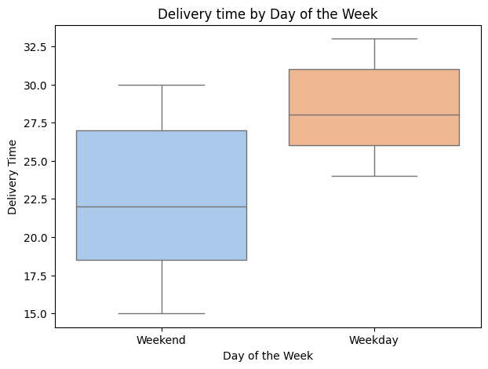

```python
# Delivery time of the orders
plt.figure(figsize=(7,5))
sns.boxplot(data=df, x='day_of_the_week', y='delivery_time', palette='pastel', hue='day_of_the_week', legend=False)
plt.title('Delivery time by Day of the Week')
plt.xlabel('Day of the Week')
plt.ylabel('Delivery Time')
plt.show()
```

### Recommendations:

- Encourage customers to provide ratings for the orders. Send emails or push notifications to customers asking for rating after delivery.
- Offer small discounts, loyalty points for submitting a rating.
- Investigate why certain cuisines have lower order volume. Conduct a market research to understand customer preferences and competitive offerings.
- Ensure adequate delivery staff is available during the weekends to handle surge in orders.
- Given the high popularity of American and Japenese cuisines, run targeted promotional offers and advertisements, especially on weekends.
- Strengthen partnership with top performing resturants, offer exclusive deals.